# Grip Project Report

25 May 2016

## Maximum grip aperture (on reach to grasp)

The maximum grip aperture is the maximum distance between the markers on the thumb and index finger during the period between when the hand left the table and when it touched the stick (this period is labeled as *grip* in our annotation system).

We fit a hierarchical (mixed effects) linear regression model.

#### The outcome (dependent) variable is:

- the maximum grip aperture (in mm)

#### The predictor (independent) variables are:

- the size of the stick in centimeters (centered at 8 cm, where 1 unit difference is 1 cm difference in stick size)
- the configuration of the fins (closed, none, open; where closed is the reference level)
- the interaction between the size of the stick and configuration of fins

There are varying intercepts by subject, and the effects of all the predictors (including interactions) are also allowed to vary by subject (these are the mixed effects). The full formula[^1] for this model is:

maxGrip ~ stickcmCentered * fins + (1 + stickcmCentered * fins | obsisSubj)

### Coefficient plot

These are the estimates of the effect sizes for the predictors (and interactions) in the model. The dot is the point estimate, the thick line is the 95% confidence interval, and the thin line the 99% confidence interval. One rule of thumb is: if the confidence intervals do not the effect is statistically significant.

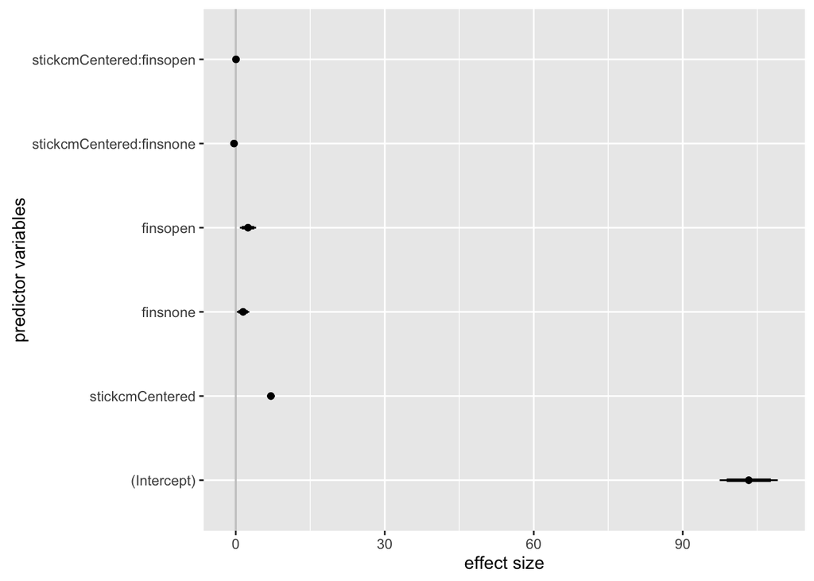

### Model predictions

These are predictions from the model for specific conditions. The dots are point estimates, and the lines are 95% confidence intervals.

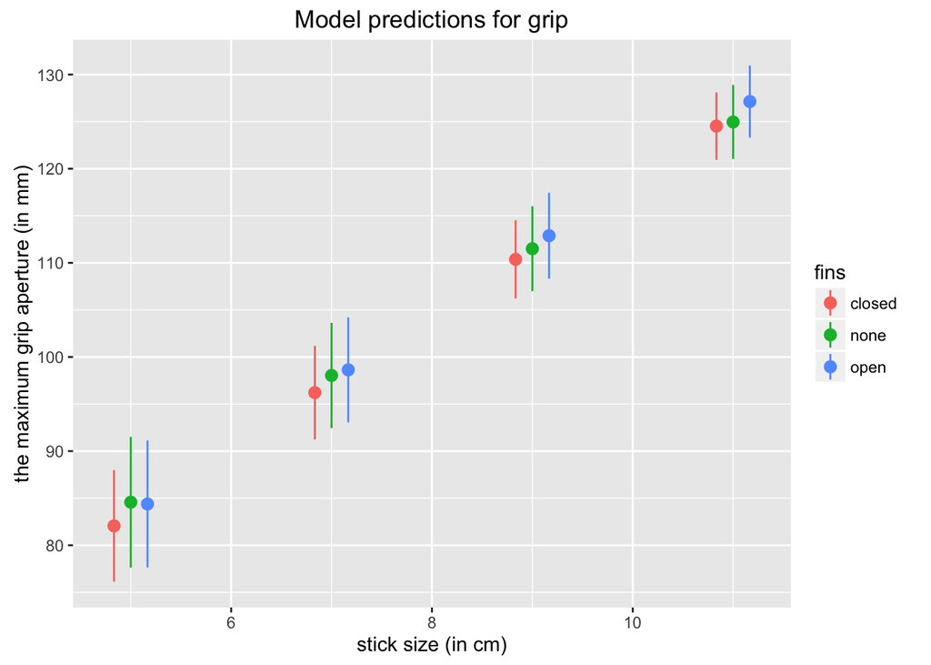

### Full model output

Hierarchical linear regression coefficient estimates and standard errors.

|  | **est. (s.e.)** |  |
| --- | --- | --- |
| (Intercept) | 103.29 (2.27)*** |  |
| stickcmCentered | 7.08 (0.31)*** |  |
| finsnone | 1.48 (0.48)** |  |
| finsopen | 2.47 (0.64)*** |  |
| stickcmCentered:finsnone | -0.35 (0.24) |  |
| stickcmCentered:finsopen | 0.05 (0.19) |  |
| AIC | 4237.63 |  |
| BIC | 4365.77 |  |
| Log Likelihood | -2090.81 |  |
| Num. obs. | 718 |  |
| Num. groups: obsisSubj | 11 |  |
| Var: obsisSubj (Intercept) | 55.88 |  |
| Var: obsisSubj stickcmCentered | 0.88 |  |
| Var: obsisSubj finsnone | 0.96 |  |
| Var: obsisSubj finsopen | 2.85 |  |
| Var: obsisSubj stickcmCentered:finsnone | 0.30 |  |
| Var: obsisSubj stickcmCentered:finsopen | 0.07 |  |
| Cov: obsisSubj (Intercept) stickcmCentered | -5.09 |  |
| Cov: obsisSubj (Intercept) finsnone | 5.64 |  |
| Cov: obsisSubj (Intercept) finsopen | 5.21 |  |
| Cov: obsisSubj (Intercept) stickcmCentered:finsnone | -1.50 |  |
| Cov: obsisSubj (Intercept) stickcmCentered:finsopen | -0.93 |  |
| Cov: obsisSubj stickcmCentered finsnone | -0.53 |  |
| Cov: obsisSubj stickcmCentered finsopen | -0.64 |  |
| Cov: obsisSubj stickcmCentered stickcmCentered:finsnone | 0.38 |  |
| Cov: obsisSubj stickcmCentered stickcmCentered:finsopen | 0.16 |  |
| Cov: obsisSubj finsnone finsopen | 1.48 |  |
| Cov: obsisSubj finsnone stickcmCentered:finsnone | -0.38 |  |
| Cov: obsisSubj finsnone stickcmCentered:finsopen | -0.22 |  |
| Cov: obsisSubj finsopen stickcmCentered:finsnone | -0.76 |  |
| Cov: obsisSubj finsopen stickcmCentered:finsopen | -0.42 |  |
| Cov: obsisSubj stickcmCentered:finsnone stickcmCentered:finsopen | 0.14 |  |
| Var: Residual | 17.39 |  |
| ***p < 0.001, <sup>**</sup style=“vertical-align: 0px;”>p < 0.01, *p < 0.05, <sup>·</sup>p < 0.1</sup> |  |  |

### Intercept and slope adjustments

There are estimates of the intercept and slope adjustments by subject. and 95% confidence intervals around those estimates. This is also referred to as the mixed effects structure and is one way to see variability between subjects.

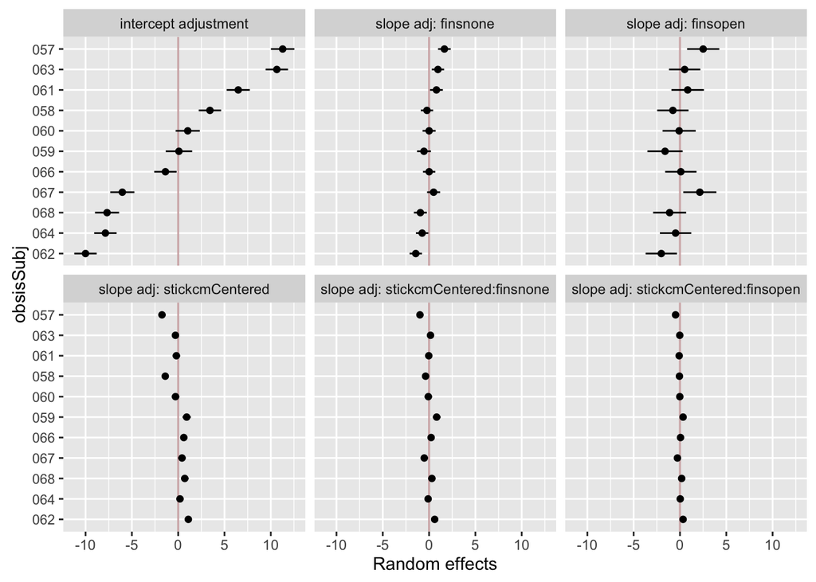

### Raw data

These are the raw data that was used in the model.

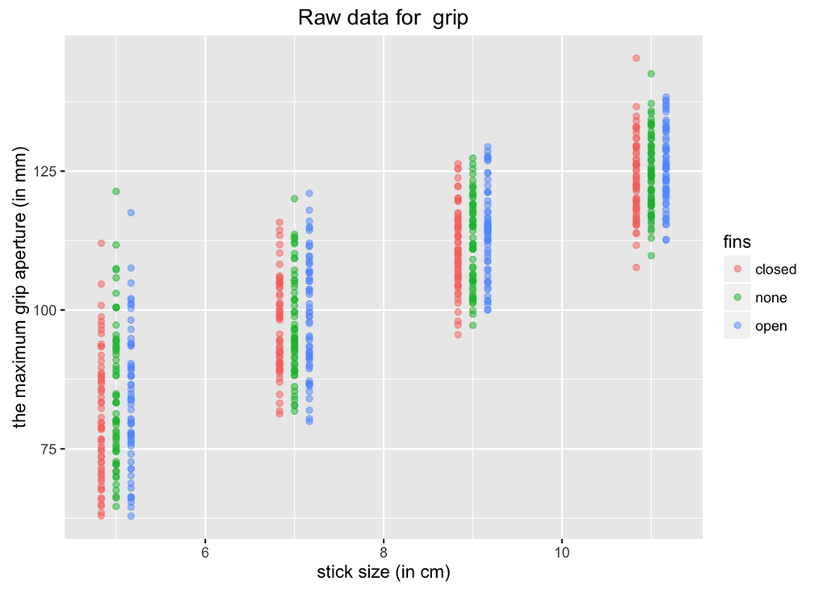

### Number of observations and occlusion

| stick | fins | n | subjs | meanPerSubj |
| --- | --- | --- | --- | --- |
| five | closed | 60 | 11 | 5.454546 |
| five | none | 60 | 11 | 5.454546 |
| five | open | 61 | 11 | 5.545454 |
| seven | closed | 59 | 11 | 5.363636 |
| seven | none | 57 | 11 | 5.181818 |
| seven | open | 58 | 11 | 5.272727 |
| nine | closed | 61 | 11 | 5.545454 |
| nine | none | 60 | 11 | 5.454546 |
| nine | open | 60 | 11 | 5.454546 |
| eleven | closed | 61 | 11 | 5.545454 |
| eleven | none | 61 | 11 | 5.545454 |
| eleven | open | 60 | 11 | 5.454546 |

There were 14 trials that were excluded because there was occlusion.

- There is 5.3191% occlusion for obsisSubj: 057 obsisTrail: 002 condition: 4 period: GRIP trial type: ACTION This observation has not been extracted because the occlusion is over the threshold of 0.05.
- There is 7.1429% occlusion for obsisSubj: 057 obsisTrail: 002 condition: 6 period: GRIP trial type: ACTION This observation has not been extracted because the occlusion is over the threshold of 0.05.
- There is 6.9565% occlusion for obsisSubj: 057 obsisTrail: 003 condition: 8 period: GRIP trial type: ACTION This observation has not been extracted because the occlusion is over the threshold of 0.05.
- There is 11.9718% occlusion for obsisSubj: 057 obsisTrail: 003 condition: 11 period: GRIP trial type: ACTION This observation has not been extracted because the occlusion is over the threshold of 0.05.
- There is 49.1667% occlusion for obsisSubj: 057 obsisTrail: 004 condition: 4 period: GRIP trial type: ACTION This observation has not been extracted because the occlusion is over the threshold of 0.05.
- There is 6.8627% occlusion for obsisSubj: 057 obsisTrail: 004 condition: 6 period: GRIP trial type: ACTION This observation has not been extracted because the occlusion is over the threshold of 0.05.
- There is 21.9409% occlusion for obsisSubj: 057 obsisTrail: 005 condition: 4 period: GRIP trial type: ACTION This observation has not been extracted because the occlusion is over the threshold of 0.05.
- There is 32.5342% occlusion for obsisSubj: 061 obsisTrail: 003 condition: 3 period: GRIP trial type: ACTION This observation has not been extracted because the occlusion is over the threshold of 0.05.
- There is 24.2424% occlusion for obsisSubj: 061 obsisTrail: 003 condition: 5 period: GRIP trial type: ACTION This observation has not been extracted because the occlusion is over the threshold of 0.05.
- There is 23.75% occlusion for obsisSubj: 061 obsisTrail: 004 condition: 4 period: GRIP trial type: ACTION This observation has not been extracted because the occlusion is over the threshold of 0.05.
- There is 31.405% occlusion for obsisSubj: 061 obsisTrail: 004 condition: 5 period: GRIP trial type: ACTION This observation has not been extracted because the occlusion is over the threshold of 0.05.
- There is 22.0779% occlusion for obsisSubj: 061 obsisTrail: 005 condition: 7 period: GRIP trial type: ACTION This observation has not been extracted because the occlusion is over the threshold of 0.05.
- There is 20% occlusion for obsisSubj: 061 obsisTrail: 006 condition: 1 period: GRIP trial type: ACTION This observation has not been extracted because the occlusion is over the threshold of 0.05.
- There is 31.6547% occlusion for obsisSubj: 061 obsisTrail: 007 condition: 5 period: GRIP trial type: ACTION This observation has not been extracted because the occlusion is over the threshold of 0.05.

## Size estimation

The mean grip aperture is the mean of the distance measurements between the markers on the thumb and index finger during the period when the subject said the word ready (this period is labeled as *steady* in our annotation system).

We fit a hierarchical (mixed effects) linear regression model.

#### The outcome (dependent) variable is:

- the mean grip aperture (in mm)

#### The predictor (independent) variables are:

- the size of the stick in centimeters (centered at 8 cm, where 1 unit difference is 1 cm difference in stick size)
- the configuration of the fins (closed, none, open; where closed is the reference level)
- the interaction between the size of the stick and configuration of fins

There are varying intercepts by subject, and the effects of all the predictors (including interactions) are also allowed to vary by subject (these are the mixed effects). The full formula[^2] for this model is:

meanGrip ~ stickcmCentered * fins + (1 + stickcmCentered * fins | obsisSubj)

### Coefficient plot

These are the estimates of the effect sizes for the predictors (and interactions) in the model. The dot is the point estimate, the thick line is the 95% confidence interval, and the thin line the 99% confidence interval. One rule of thumb is: if the confidence intervals do not the effect is statistically significant.

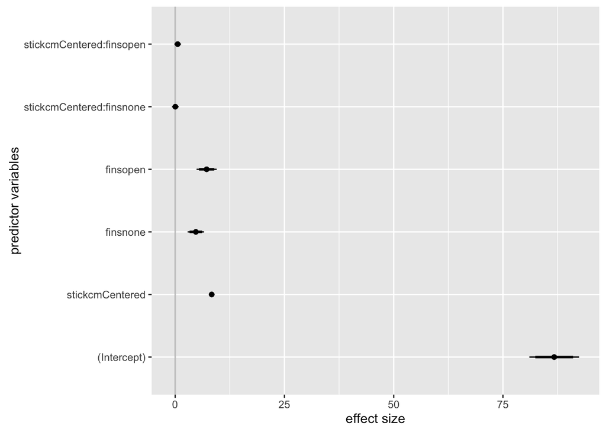

### Model predictions

These are predictions from the model for specific conditions. The dots are point estimates, and the lines are 95% confidence intervals.

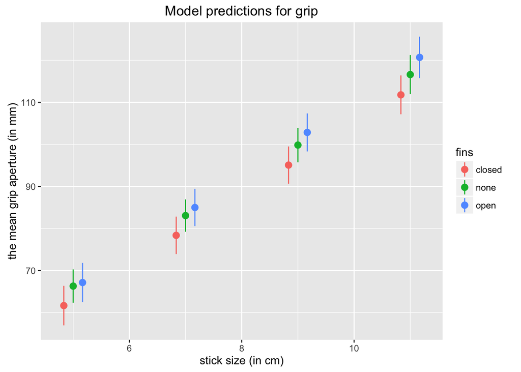

### Full model output

Hierarchical linear regression coefficient estimates and standard errors.

|  | **est. (s.e.)** |  |
| --- | --- | --- |
| (Intercept) | 86.73 (2.21)*** |  |
| stickcmCentered | 8.35 (0.25)*** |  |
| finsnone | 4.73 (0.73)*** |  |
| finsopen | 7.20 (0.89)*** |  |
| stickcmCentered:finsnone | 0.03 (0.30) |  |
| stickcmCentered:finsopen | 0.57 (0.30)<sup>·</sup> |  |
| AIC | 4489.99 |  |
| BIC | 4617.46 |  |
| Log Likelihood | -2217.00 |  |
| Num. obs. | 701 |  |
| Num. groups: obsisSubj | 11 |  |
| Var: obsisSubj (Intercept) | 52.16 |  |
| Var: obsisSubj stickcmCentered | 0.40 |  |
| Var: obsisSubj finsnone | 3.10 |  |
| Var: obsisSubj finsopen | 5.92 |  |
| Var: obsisSubj stickcmCentered:finsnone | 0.41 |  |
| Var: obsisSubj stickcmCentered:finsopen | 0.41 |  |
| Cov: obsisSubj (Intercept) stickcmCentered | -0.18 |  |
| Cov: obsisSubj (Intercept) finsnone | -7.13 |  |
| Cov: obsisSubj (Intercept) finsopen | -2.79 |  |
| Cov: obsisSubj (Intercept) stickcmCentered:finsnone | 0.90 |  |
| Cov: obsisSubj (Intercept) stickcmCentered:finsopen | -0.44 |  |
| Cov: obsisSubj stickcmCentered finsnone | 0.09 |  |
| Cov: obsisSubj stickcmCentered finsopen | -0.25 |  |
| Cov: obsisSubj stickcmCentered stickcmCentered:finsnone | -0.04 |  |
| Cov: obsisSubj stickcmCentered stickcmCentered:finsopen | -0.03 |  |
| Cov: obsisSubj finsnone finsopen | 3.73 |  |
| Cov: obsisSubj finsnone stickcmCentered:finsnone | 0.56 |  |
| Cov: obsisSubj finsnone stickcmCentered:finsopen | 0.85 |  |
| Cov: obsisSubj finsopen stickcmCentered:finsnone | 1.24 |  |
| Cov: obsisSubj finsopen stickcmCentered:finsopen | 1.44 |  |
| Cov: obsisSubj stickcmCentered:finsnone stickcmCentered:finsopen | 0.39 |  |
| Var: Residual | 29.17 |  |
| ***p < 0.001, <sup>**</sup style=“vertical-align: 0px;”>p < 0.01, *p < 0.05, <sup>·</sup>p < 0.1</sup> |  |  |

### Intercept and slope adjustments

There are estimates of the intercept and slope adjustments by subject. and 95% confidence intervals around those estimates. This is also referred to as the mixed effects structure and is one way to see variability between subjects.

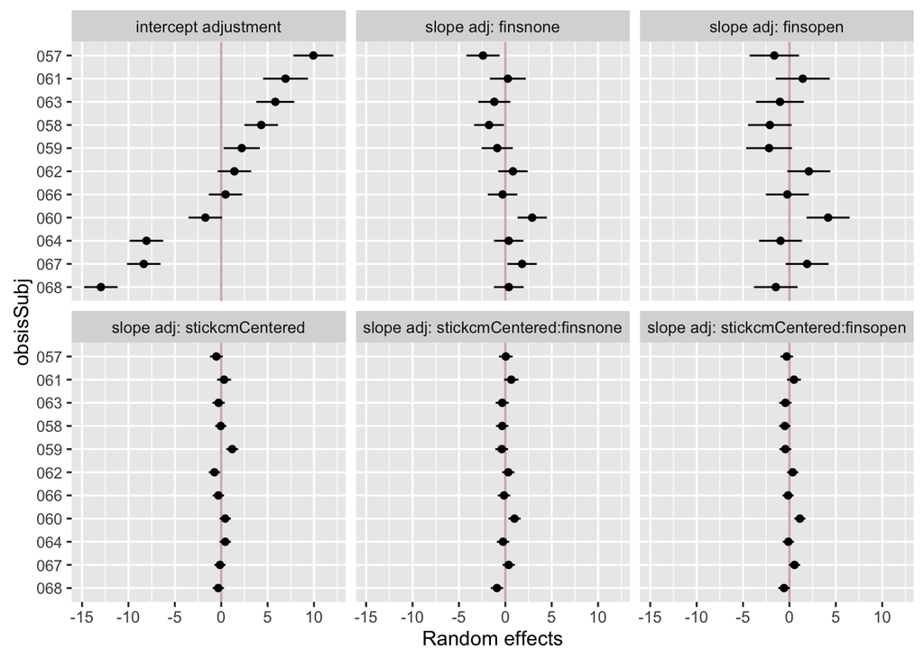

### Raw data

These are the raw data that was used in the model.

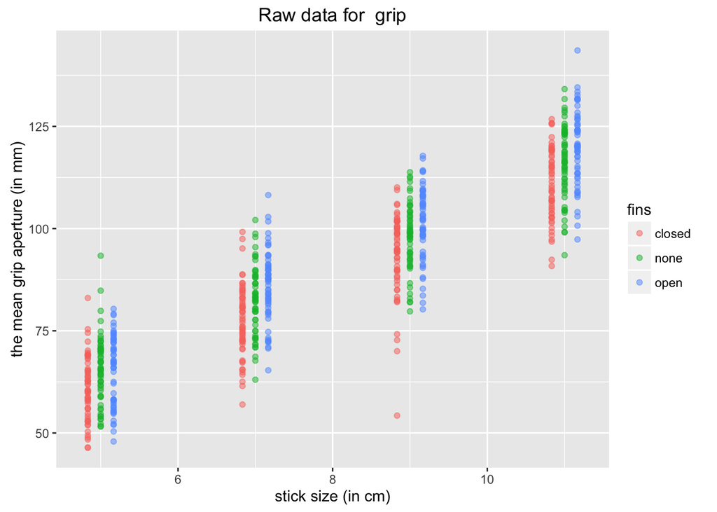

### Number of observations and occlusion

| stick | fins | n | subjs | meanPerSubj |
| --- | --- | --- | --- | --- |
| five | closed | 59 | 11 | 5.363636 |
| five | none | 59 | 11 | 5.363636 |
| five | open | 59 | 11 | 5.363636 |
| seven | closed | 59 | 11 | 5.363636 |
| seven | none | 56 | 11 | 5.090909 |
| seven | open | 59 | 11 | 5.363636 |
| nine | closed | 58 | 11 | 5.272727 |
| nine | none | 59 | 11 | 5.363636 |
| nine | open | 58 | 11 | 5.272727 |
| eleven | closed | 58 | 11 | 5.272727 |
| eleven | none | 60 | 11 | 5.454546 |
| eleven | open | 57 | 11 | 5.181818 |

There were 9 trials that were excluded because there was occlusion.

- There is 87% occlusion for obsisSubj: 057 obsisTrail: 013 condition: 1 period: STEADY trial type: ESTIMATION This observation has not been extracted because the occlusion is over the threshold of 0.05.
- There is 100% occlusion for obsisSubj: 063 obsisTrail: 010 condition: 2 period: STEADY trial type: ESTIMATION This observation has not been extracted because the occlusion is over the threshold of 0.05.
- There is 100% occlusion for obsisSubj: 063 obsisTrail: 010 condition: 4 period: STEADY trial type: ESTIMATION This observation has not been extracted because the occlusion is over the threshold of 0.05.
- There is 100% occlusion for obsisSubj: 063 obsisTrail: 010 condition: 8 period: STEADY trial type: ESTIMATION This observation has not been extracted because the occlusion is over the threshold of 0.05.
- There is 100% occlusion for obsisSubj: 063 obsisTrail: 012 condition: 6 period: STEADY trial type: ESTIMATION This observation has not been extracted because the occlusion is over the threshold of 0.05.
- There is 100% occlusion for obsisSubj: 063 obsisTrail: 012 condition: 7 period: STEADY trial type: ESTIMATION This observation has not been extracted because the occlusion is over the threshold of 0.05.
- There is 100% occlusion for obsisSubj: 063 obsisTrail: 012 condition: 9 period: STEADY trial type: ESTIMATION This observation has not been extracted because the occlusion is over the threshold of 0.05.
- There is 100% occlusion for obsisSubj: 063 obsisTrail: 012 condition: 12 period: STEADY trial type: ESTIMATION This observation has not been extracted because the occlusion is over the threshold of 0.05.
- There is 65% occlusion for obsisSubj: 063 obsisTrail: 013 condition: 4 period: STEADY trial type: ESTIMATION This observation has not been extracted because the occlusion is over the threshold of 0.05.
[^1]: See [the lme4 documentation](https://cran.r-project.org/web/packages/lme4/vignettes/lmer.pdf) (especially section 2) for explanation of the formula format.
[^2]: See [the lme4 documentation](https://cran.r-project.org/web/packages/lme4/vignettes/lmer.pdf) (especially section 2) for explanation of the formula format.